# Playing Habits of Lancer Players

## Long-term players tend to play more modules.

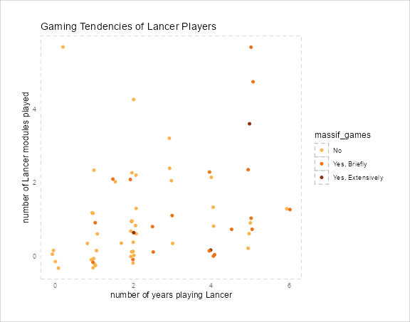

This is relatively straightforward, given how lancer modules take several months to complete and campaign play is relatively rare among people on open-table discord servers. There is notably a large spike in the amount of datapoints at 2 years of play, likely as a result of the print edition of the game coming out that year. Additionally there is a large vertical grouping at the 5 year mark, coinciding with covid. Suggesting that players were more actively engaged with campaigns via online play during the pandemic.

## Game masters are more likely to play in prewritten modules than people who are exclusively players.

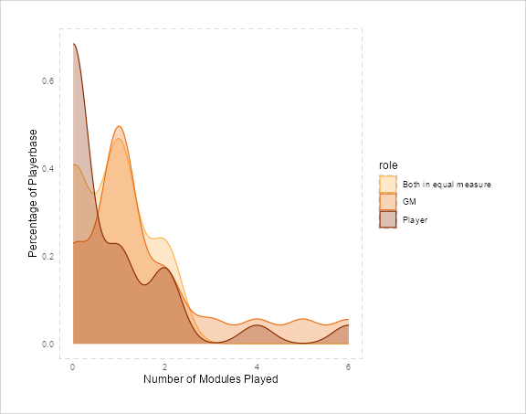

A transparent fill effect was used to emphasise area covered and make the lines more evident and distinct

GMs consistently play more modules than players despite making up a smaller portion of the polled population. This is likely a result of GMs being more invested in the hobby than ordinary players and are more pro-active within their communities making them more likely to end up playing in more long-term game formats.

## Survey Response Times

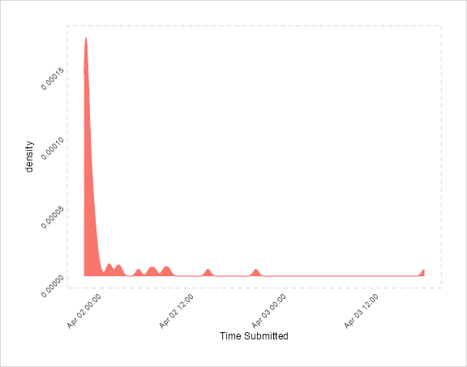

Axes figures were tilted to avoid overlapping

The response times for the survey were very quick, with the vast majority coming in the first 2 hours. The time I posted the quiz was during peak hours for the American time zones, which had the majority of players in the discord servers the survey was shared in.